# project_Hayk

```python
import pandas as pd
import numpy as np
import matplotlib.pyplot as plt
```

The code reads data from an Excel file named "carbon_data.xlsx" using pandas.

1. First, it opens the Excel file and stores it in the variable `data` using the `pd.ExcelFile` function.
2. Then, it reads the data from the second sheet (indexed at 1) of the Excel file into a pandas DataFrame named `carbon_data` using the `pd.read_excel` function.

This code snippet allows for easy importation and manipulation of data from Excel files into Python using pandas, enabling further analysis and visualization.

```python
data = pd.ExcelFile("carbon_data.xlsx")
carbon_data = pd.read_excel(data, sheet_name=1)
```

```python
carbon_data
```

|  | Body Type | Sex | Diet | How Often Shower | Heating Energy Source | Transport | Vehicle Type | Social Activity | Monthly Grocery Bill | Frequency of Traveling by Air | Vehicle Monthly Distance Km | Waste Bag Size | Waste Bag Weekly Count | How Long TV PC Daily Hour | How Many New Clothes Monthly | How Long Internet Daily Hour | Energy efficiency | Recycling | Cooking_With | CarbonEmission |
| --- | --- | --- | --- | --- | --- | --- | --- | --- | --- | --- | --- | --- | --- | --- | --- | --- | --- | --- | --- | --- |
| 0 | overweight | female | pescatarian | daily | coal | public | NaN | often | 230 | frequently | 210 | large | 4 | 7 | 26 | 1 | No | ['Metal'] | ['Stove', 'Oven'] | 2238 |
| 1 | obese | female | vegetarian | less frequently | natural gas | walk/bicycle | NaN | often | 114 | rarely | 9 | extra large | 3 | 9 | 38 | 5 | No | ['Metal'] | ['Stove', 'Microwave'] | 1892 |
| 2 | overweight | male | omnivore | more frequently | wood | private | petrol | never | 138 | never | 2472 | small | 1 | 14 | 47 | 6 | Sometimes | ['Metal'] | ['Oven', 'Microwave'] | 2595 |
| 3 | overweight | male | omnivore | twice a day | wood | walk/bicycle | NaN | sometimes | 157 | rarely | 74 | medium | 3 | 20 | 5 | 7 | Sometimes | ['Paper', 'Plastic', 'Glass', 'Metal'] | ['Microwave', 'Grill', 'Airfryer'] | 1074 |
| 4 | obese | female | vegetarian | daily | coal | private | diesel | often | 266 | very frequently | 8457 | large | 1 | 3 | 5 | 6 | Yes | ['Paper'] | ['Oven'] | 4743 |
| ... | ... | ... | ... | ... | ... | ... | ... | ... | ... | ... | ... | ... | ... | ... | ... | ... | ... | ... | ... | ... |
| 9995 | obese | male | omnivore | twice a day | coal | private | hybrid | sometimes | 230 | never | 268 | medium | 5 | 12 | 27 | 9 | Yes | [] | ['Microwave'] | 2408 |
| 9996 | normal | female | vegan | twice a day | coal | private | lpg | never | 234 | frequently | 5316 | extra large | 3 | 14 | 8 | 24 | Sometimes | ['Paper', 'Plastic'] | ['Stove', 'Microwave'] | 3084 |
| 9997 | overweight | female | vegetarian | daily | electricity | walk/bicycle | NaN | sometimes | 298 | very frequently | 96 | extra large | 5 | 11 | 5 | 24 | Yes | ['Paper', 'Plastic', 'Metal'] | ['Microwave', 'Grill', 'Airfryer'] | 2377 |
| 9998 | underweight | male | vegan | more frequently | coal | private | petrol | often | 179 | rarely | 8688 | medium | 5 | 19 | 14 | 5 | Sometimes | ['Paper', 'Metal'] | ['Stove', 'Microwave', 'Grill', 'Airfryer'] | 4574 |
| 9999 | obese | male | pescatarian | twice a day | wood | private | electric | sometimes | 115 | never | 9952 | small | 4 | 11 | 6 | 0 | Sometimes | ['Plastic', 'Glass', 'Metal'] | ['Oven', 'Grill', 'Airfryer'] | 826 |

10000 rows × 20 columns

The code generates a bar plot showing the average daily time spent on the internet by individuals following different diets. The data is grouped by the 'Diet' column, and the mean of the 'How Long Internet Daily Hour' column is calculated for each group. The resulting grouped data is then visualized using matplotlib.

- The x-axis represents the different diets.
- The y-axis represents the average daily time spent on the internet in hours.
- Each bar corresponds to a diet category, with the height indicating the average time spent on the internet.

The bars are color-coded for visual distinction, using shades of blue ('#016064', '#48AAAD', '#022D36','#1F456E'). Grid lines are included for better readability.

The figure size is set to (7.5, 5) inches to ensure proper visualization, and tight layout adjustment is applied to avoid overlapping elements. Finally, the plot is displayed using plt.show().

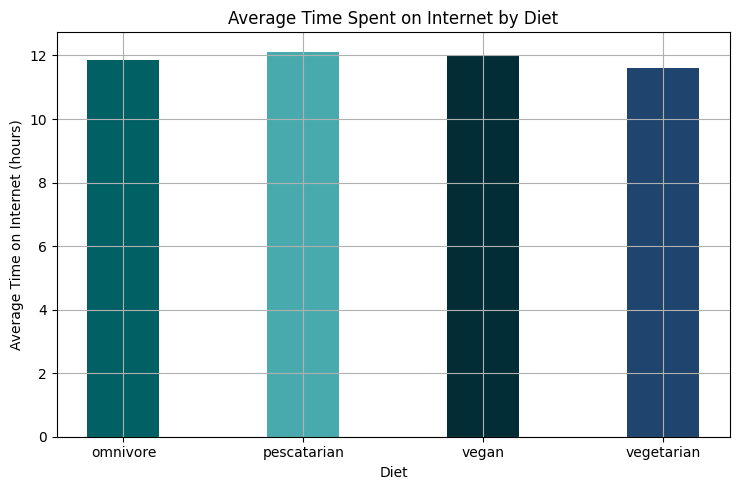

```python
grouped_data = carbon_data.groupby('Diet')['How Long Internet Daily Hour'].mean().reset_index()
plt.figure(figsize=(7.5, 5))

plt.bar(grouped_data['Diet'], grouped_data['How Long Internet Daily Hour'], color=['#016064', '#48AAAD', '#022D36','#1F456E'],width=0.4)
plt.title('Average Time Spent on Internet by Diet')
plt.xlabel('Diet')
plt.ylabel('Average Time on Internet (hours)')

plt.grid(True)
plt.tight_layout()

plt.show()
```

The code generates a bar plot showing the average monthly distance traveled by vehicles for different transportation modes. The data is grouped by the 'Transport' column, and the mean of the 'Vehicle Monthly Distance Km' column is calculated for each group. The resulting grouped data is then visualized using matplotlib.

- The x-axis represents the transportation modes.
- The y-axis represents the average distance traveled in kilometers.
- Each bar corresponds to a transportation mode, with the height indicating the average distance traveled.

The bars are color-coded for visual distinction, using shades of blue ('#016064', '#48AAAD', '#022D36','#1F456E'). Grid lines are included for better readability.

The figure size is set to (7.5, 5) inches to ensure proper visualization, and tight layout adjustment is applied to avoid overlapping elements. Finally, the plot is displayed using plt.show().

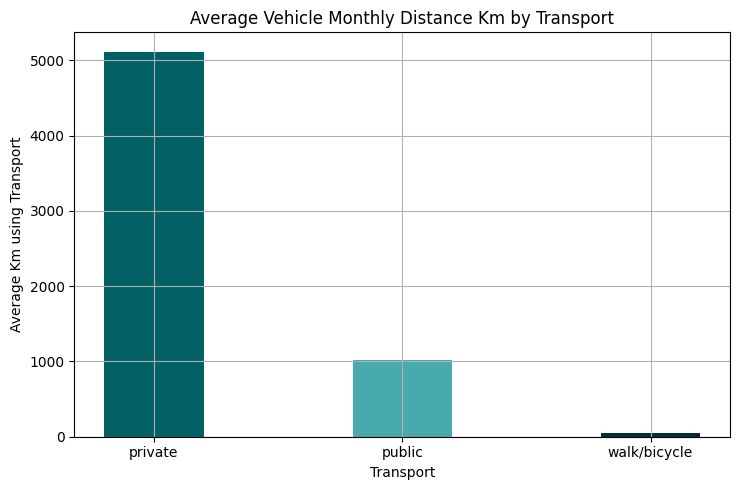

```python
grouped_data = carbon_data.groupby('Transport')['Vehicle Monthly Distance Km'].mean().reset_index()
plt.figure(figsize=(7.5, 5))

plt.bar(grouped_data['Transport'], grouped_data['Vehicle Monthly Distance Km'], color=['#016064', '#48AAAD', '#022D36','#1F456E'],width=0.4)
plt.title('Average Vehicle Monthly Distance Km by Transport')
plt.xlabel('Transport')
plt.ylabel('Average Km using Transport')

plt.grid(True)
plt.tight_layout()

plt.show()
```

The code generates a pie chart to illustrate the distribution of average monthly distances traveled by vehicles across various transportation modes.

The data in the DataFrame `carbon_data` is grouped by the transportation mode ('Transport') column, and the mean monthly distance traveled ('Vehicle Monthly Distance Km') is calculated for each group. The resulting grouped data is stored in the variable `grouped_data`.

A pie chart is created using matplotlib's `plt.pie()` function. Each slice of the pie represents a transportation mode, and its size corresponds to the average monthly distance traveled by vehicles for that mode.

The pie chart is colored using predefined color codes to enhance visual clarity.

The title of the pie chart indicates its purpose: to display the average vehicle monthly distance by transport mode.

Tight layout adjustment is applied to ensure proper spacing of plot elements.

A legend is included in the plot, positioned for optimal readability. The legend labels correspond to the different transportation modes.

Finally, the plot is displayed using `plt.show()`.

This visualization provides an intuitive representation of how the average monthly distances traveled by vehicles are distributed among different transportation modes.

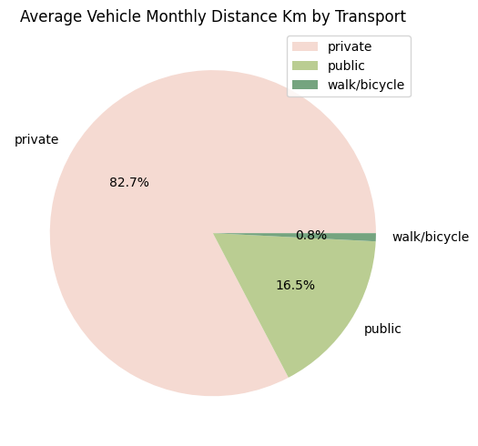

```python
grouped_data = carbon_data.groupby('Transport')['Vehicle Monthly Distance Km'].mean().reset_index()

plt.figure(figsize=(7.5, 5))

plt.pie(grouped_data['Vehicle Monthly Distance Km'], labels=grouped_data['Transport'], colors=[ '#F5DAD2', '#BACD92', '#75A47F'], autopct='%1.1f%%')

plt.title('Average Vehicle Monthly Distance Km by Transport')

plt.tight_layout()
plt.legend(loc="best", labels=grouped_data['Transport'])

plt.show()
```